# Yusha PDAC Factor 3

```r
library(glmnet)
library(logisticsusie)
library(dplyr)

tar_load(ibss_fit_pdac_factor3)
tar_load(pdac_lasso_fits)
tar_load(pdac_msigdb_X)
tar_load(pdac_data)
tar_load(ibss_fit_marginal_only_pdac_factor3)

lasso_fit_pdac_factor3 <- pdac_lasso_fits$factor3
coef_1sd <- coef(lasso_fit_pdac_factor3, s = 'lambda.1se')[,1]
nonzero_idx <- which(tail(coef_1sd, -1) != 0)
X <- pdac_msigdb_X
y <- as.integer(rownames(X) %in% pdac_data$gene_lists$factor3)
```

## Looking at PDAC `factor3`

The gene list consists of the top 129 genes in `factor3` of Yusha’s matrix factorization (NMF?) fit to the pancreatic ductal adenocarcinoma (PDAC) data. Yusha provided (i) a list of background genes and (ii) the top 139 genes associated with each factor (how was this determined?). For `factor3` 10 genes were filtered out due to the gene symbols not mapping to ENTREZIDs when using the `org.Hs.eg.db` annotation.

These data were used to perform the standard marginal overrperesentation analysis (ORA) via Fisher’s exact test. We also fit lasso using `glmnet`, and run “generalized IBSS” (GIBSS) with $L=8$ effects.

### ORA

Marginal results summary:

- There are 304 marginally enriched gene sets
- 14 gene sets reported in lasso fit for `lambda.1se` (the penalty parameter within 1 standard error of the penalty parameter that minimized CV loss when running `cv.glmnet`)

```r
ora_pdac_factor3 <- gseasusie::fit_ora(X, y)
```

```
## computing ORA statistics...
```

```
## 4.255 sec elapsed
```

```r
gs_df <- data.frame(
    geneSet = colnames(X),
    n = 1:ncol(X),
    pip = logisticsusie::compute_pip(ibss_fit_pdac_factor3$alpha)
)

ora_pdac_factor3 <- ora_pdac_factor3 %>%
    left_join(gs_df) %>%
    arrange(pFishersExact) %>%
    mutate(rank = row_number(), pAdj = p.adjust(pFishersExact, method='BH')) %>%
    select(geneSet, n, rank, pip, oddsRatio, pFishersExact, pAdj)
ora_pdac_factor3 %>%
    filter(pAdj < 0.05) %>%
    knitr::kable()
```

| geneSet | n | rank | pip | oddsRatio | pFishersExact | pAdj |
| --- | --- | --- | --- | --- | --- | --- |
| M11197 | 1139 | 1 | 1.0000000 | 31.4282166 | 0.0000000 | 0.0000000 |
| M2534 | 2124 | 2 | 0.2949092 | 23.9990584 | 0.0000000 | 0.0000000 |
| M15669 | 944 | 3 | 0.9998359 | 60.2384868 | 0.0000000 | 0.0000000 |
| M5792 | 1638 | 4 | 0.9988693 | 14.7530612 | 0.0000000 | 0.0000000 |
| M73 | 3672 | 5 | 0.0801864 | 27.5223130 | 0.0000000 | 0.0000000 |
| M2567 | 2011 | 6 | 0.0437639 | 38.5052632 | 0.0000000 | 0.0000000 |
| M2107 | 1467 | 7 | 0.0001055 | 6.4004959 | 0.0000000 | 0.0000000 |
| M41837 | 2509 | 8 | 0.0190880 | 13.2717505 | 0.0000000 | 0.0000000 |
| M17673 | 1322 | 9 | 0.2905433 | 37.5435897 | 0.0000000 | 0.0000000 |
| M10791 | 759 | 10 | 0.0005026 | 6.3183965 | 0.0000000 | 0.0000000 |
| M2105 | 1465 | 11 | 0.0000372 | 5.6218505 | 0.0000000 | 0.0000000 |
| M27620 | 2905 | 12 | 0.3085673 | 6.7647401 | 0.0000000 | 0.0000000 |
| M1036 | 2770 | 13 | 0.0039625 | 5.0467180 | 0.0000000 | 0.0000000 |
| M39417 | 4064 | 14 | 0.1101723 | 18.1167702 | 0.0000000 | 0.0000000 |
| M7272 | 1402 | 15 | 0.1630987 | 15.4477929 | 0.0000000 | 0.0000000 |
| M13486 | 1368 | 16 | 0.0369564 | 10.6662621 | 0.0000000 | 0.0000000 |
| M18264 | 1933 | 17 | 0.1352698 | 17.3921497 | 0.0000000 | 0.0000000 |
| M39881 | 4214 | 18 | 0.0755031 | 32.3839009 | 0.0000000 | 0.0000000 |
| M16024 | 1302 | 19 | 0.0150099 | 11.5060241 | 0.0000000 | 0.0000000 |
| M19982 | 3853 | 20 | 0.9759426 | 6.8026961 | 0.0000000 | 0.0000000 |
| M27495 | 3281 | 21 | 0.0008357 | 13.8319696 | 0.0000000 | 0.0000000 |
| M5190 | 1802 | 22 | 0.0049545 | 15.9170758 | 0.0000000 | 0.0000000 |
| M19540 | 1399 | 23 | 0.0321529 | 12.9466338 | 0.0000000 | 0.0000001 |
| M1484 | 1175 | 24 | 0.3644369 | 10.0360111 | 0.0000000 | 0.0000001 |
| M17363 | 1474 | 25 | 0.0056580 | 27.4537500 | 0.0000000 | 0.0000001 |
| M15112 | 3960 | 26 | 0.0331149 | 7.5327586 | 0.0000000 | 0.0000003 |
| M9375 | 661 | 27 | 0.0005249 | 21.9480000 | 0.0000000 | 0.0000006 |
| M19251 | 3716 | 28 | 0.0002155 | 28.4842003 | 0.0000000 | 0.0000009 |
| M17728 | 298 | 29 | 0.0001091 | 3.5554115 | 0.0000000 | 0.0000009 |
| M27244 | 2591 | 30 | 0.0144375 | 26.8980716 | 0.0000000 | 0.0000012 |

[output cut: 274 more lines]

```r
# filter to variables included by lasso
ora_pdac_factor3 %>%
    filter(n %in% nonzero_idx) %>%
    knitr::kable()
```

| geneSet | n | rank | pip | oddsRatio | pFishersExact | pAdj |
| --- | --- | --- | --- | --- | --- | --- |
| M11197 | 1139 | 1 | 1.0000000 | 31.428217 | 0e+00 | 0.00e+00 |
| M2534 | 2124 | 2 | 0.2949092 | 23.999058 | 0e+00 | 0.00e+00 |
| M15669 | 944 | 3 | 0.9998359 | 60.238487 | 0e+00 | 0.00e+00 |
| M5792 | 1638 | 4 | 0.9988693 | 14.753061 | 0e+00 | 0.00e+00 |
| M73 | 3672 | 5 | 0.0801864 | 27.522313 | 0e+00 | 0.00e+00 |
| M2567 | 2011 | 6 | 0.0437639 | 38.505263 | 0e+00 | 0.00e+00 |
| M17673 | 1322 | 9 | 0.2905433 | 37.543590 | 0e+00 | 0.00e+00 |
| M19982 | 3853 | 20 | 0.9759426 | 6.802696 | 0e+00 | 0.00e+00 |
| M1484 | 1175 | 24 | 0.3644369 | 10.036011 | 0e+00 | 1.00e-07 |
| M17363 | 1474 | 25 | 0.0056580 | 27.453750 | 0e+00 | 1.00e-07 |
| M27244 | 2591 | 30 | 0.0144375 | 26.898072 | 0e+00 | 1.20e-06 |
| M3432 | 1612 | 36 | 0.0306900 | 17.130469 | 0e+00 | 2.90e-06 |
| M16962 | 1179 | 41 | 0.0173731 | 39.739837 | 1e-07 | 1.16e-05 |
| M8924 | 3856 | 61 | 0.8697365 | 23.824390 | 1e-06 | 7.77e-05 |

IBSS results are summarized here:

- Returns 4 singleton CSs. All variables also in the lasso solution, and in the top 20 marginal enrichments.
- 1 CS (`L6`) with 11 variables. These 11 variables are all among the top 30 marginally enriched, and not very correlated (CS has a purity of $\approx 0.09$). Rather than representing a coherent enrichment/association signal this CS captures several independent enrichments that were not strong enough to capture a different single effect.
- `L5` gives a credible set with 224 variables, and low purity. The top variable in this CS has a posterior probability of $0.87$. This is an example of a “borderline significant result”. `L7` and `L8` are similar, except with the top variable having a smaller probabilty ($0.36$ and $0.29$ respectively). In all cases these are strongly marginally enriched and identified in the lasso solution.
- Stopped at the maximum of 20 iterations, the symmetrized KL between with approximate posterior at the last two iterations $KL_{sym}[q^{t=19} || q^{t=20}] \approx 1e-6$ which I am guessing is small enough that the solution would not change much qualitatively by futher iteration. I will run for longer to see what happens.
- IBSS was fit here with an adaptive procedure that would increase $L$ as long as all the existing single effects look “informative”. That is
1. have relatively small CSs,
2. the estimate prior variance for all effects is not below some threshold,
3. the BF for all single effect regressions does not fall below some threshold. If all 3 of these conditions are satified then IBSS is rerun with $L$ doubled.

### IBSS overview

IBSS results are summarized here:

- Returns 4 singleton CSs. All variables also in the lasso solution, and in the top 20 marginal enrichments.
- 1 CS (`L6`) with 11 variables. These 11 variables are all among the top 30 marginally enriched, and not very correlated (CS has a purity of $\approx 0.09$ ). Rather than representing a coherent enrichment/association signal this CS captures several independent enrichments that were not strong enough to capture a different single effect.
- `L5` gives a credible set with 224 variables, and low purity. The top variable in this CS has a posterior probability of 0.87. This is an example of a “borderline significant result”. L7 and L8 are similar, except with the top variable having a smaller probabilty (0.36 and 0.29 respectively). In all cases these are strongly marginally enriched and identified in the lasso solution.
- Stopped at the maximum of 20 iterations, the symmetrized KL between with approximate posterior at the last two iterations $KL_{sym}[q_{t=19}||q_{t=20}]≈1e−6$ which I am guessing is small enough that the solution would not change much qualitatively by futher iteration. I will run for longer to see what happens.
- IBSS was fit here with an adaptive procedure that would increase L as long as all the existing single effects look “informative”. That is
  1. have relatively small CSs
  2. the estimate prior variance for all effects is not below some threshold,
  3. the BF for all single effect regressions does not fall below some threshold. If all 3 of these conditions are satified then IBSS is rerun with L doubled.

```r
ibss_fit_pdac_factor3$cs
```

```
## $L1
## CS = {1139}
##  alpha = {1}
##  size = 1, coverage = 1, requested = 0.95
## $L2
## CS = {3853}
##  alpha = {0.98}
##  size = 1, coverage = 0.976, requested = 0.95
## $L3
## CS = {944}
##  alpha = {1}
##  size = 1, coverage = 1, requested = 0.95
## $L4
## CS = {1638}
##  alpha = {1}
##  size = 1, coverage = 0.999, requested = 0.95
## $L5
## CS = {3856, 928, 620, 1179, 1665, 1612, ...}
##  alpha = {0.87, 0.02, 0.01, 0, 0, 0, ...}
##  size = 224, coverage = 0.95, requested = 0.95
## $L6
## CS = {1322, 1402, 1933, 4064, 4214, 3672, ...}
##  alpha = {0.29, 0.16, 0.14, 0.11, 0.07, 0.06, ...}
##  size = 11, coverage = 0.962, requested = 0.95
## $L7
## CS = {1175, 2905, 928, 620, 2011, 1606, ...}
##  alpha = {0.36, 0.31, 0.03, 0.01, 0.01, 0.01, ...}
##  size = 1804, coverage = 0.95, requested = 0.95
## $L8
## CS = {2124, 928, 620, 2011, 1612, 3672, ...}
##  alpha = {0.29, 0.07, 0.03, 0.03, 0.02, 0.02, ...}
##  size = 2837, coverage = 0.95, requested = 0.95
```

```r
ibss_fit_pdac_factor3$prior_variance
```

```
##        L1        L2        L3        L4        L5        L6        L7        L8
##  8.918366  3.707231  9.554023  4.086693 13.158579  6.806948  2.827734  3.158217
```

```r
ibss_fit_pdac_factor3$lbf_ser
```

```
##        L1        L2        L3        L4        L5        L6        L7        L8
## 75.090948  4.836087  9.841050  7.893266  3.042665  4.835500  2.240658  1.405044
```

### L6– low purity, multiple independent enrichments

```r
# look at credibls set 6 in glm-susie fit
ora_pdac_factor3 %>%
    filter(n %in% ibss_fit_pdac_factor3$cs$L6$cs) %>%
    knitr::kable()
```

| geneSet | n | rank | pip | oddsRatio | pFishersExact | pAdj |
| --- | --- | --- | --- | --- | --- | --- |
| M73 | 3672 | 5 | 0.0801864 | 27.522313 | 0 | 0e+00 |
| M41837 | 2509 | 8 | 0.0190880 | 13.271750 | 0 | 0e+00 |
| M17673 | 1322 | 9 | 0.2905433 | 37.543590 | 0 | 0e+00 |
| M39417 | 4064 | 14 | 0.1101723 | 18.116770 | 0 | 0e+00 |
| M7272 | 1402 | 15 | 0.1630987 | 15.447793 | 0 | 0e+00 |
| M13486 | 1368 | 16 | 0.0369564 | 10.666262 | 0 | 0e+00 |
| M18264 | 1933 | 17 | 0.1352698 | 17.392150 | 0 | 0e+00 |
| M39881 | 4214 | 18 | 0.0755031 | 32.383901 | 0 | 0e+00 |
| M16024 | 1302 | 19 | 0.0150099 | 11.506024 | 0 | 0e+00 |
| M19540 | 1399 | 23 | 0.0321529 | 12.946634 | 0 | 1e-07 |
| M15112 | 3960 | 26 | 0.0331149 | 7.532759 | 0 | 3e-07 |

```r
logisticsusie::compute_purity(ibss_fit_pdac_factor3$cs$L6$cs, X)
```

```
## [1] 0.09404576
```

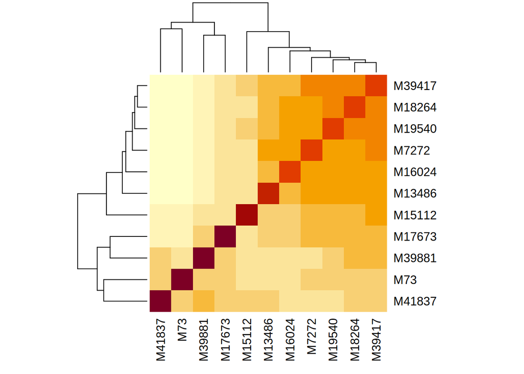

```r
heatmap(cor(as.matrix(X[, ibss_fit_pdac_factor3$cs$L6$cs])))
```

### Marginal enrichments only

```r
marginal_enrichments_idx <- ora_pdac_factor3 %>%
    filter(pAdj < 0.05) %>%
    { .$n}

ibss_fit_marginal_only_pdac_factor3$cs
```

```
## $L1
## CS = {59}
##  alpha = {1}
##  size = 1, coverage = 1, requested = 0.95
## $L2
## CS = {132, 46, 29}
##  alpha = {0.92, 0.02, 0.01}
##  size = 3, coverage = 0.956, requested = 0.95
## $L3
## CS = {47}
##  alpha = {1}
##  size = 1, coverage = 0.999, requested = 0.95
## $L4
## CS = {106}
##  alpha = {1}
##  size = 1, coverage = 0.999, requested = 0.95
## $L5
## CS = {46, 29, 268, 266, 65, 195, ...}
##  alpha = {0.41, 0.18, 0.03, 0.03, 0.02, 0.02, ...}
##  size = 92, coverage = 0.951, requested = 0.95
## $L6
## CS = {46, 29, 268, 266, 65, 195, ...}
##  alpha = {0.41, 0.18, 0.03, 0.03, 0.02, 0.02, ...}
##  size = 92, coverage = 0.951, requested = 0.95
## $L7
## CS = {46, 29, 268, 266, 65, 195, ...}
##  alpha = {0.41, 0.18, 0.03, 0.03, 0.02, 0.02, ...}
##  size = 92, coverage = 0.951, requested = 0.95
## $L8
## CS = {46, 29, 268, 266, 65, 195, ...}
##  alpha = {0.41, 0.18, 0.03, 0.03, 0.02, 0.02, ...}
##  size = 92, coverage = 0.951, requested = 0.95
## $L9
## CS = {46, 29, 268, 266, 65, 195, ...}
##  alpha = {0.41, 0.18, 0.03, 0.03, 0.02, 0.02, ...}
##  size = 92, coverage = 0.951, requested = 0.95
## $L10
## CS = {46, 29, 268, 266, 65, 195, ...}
##  alpha = {0.41, 0.18, 0.03, 0.03, 0.02, 0.02, ...}
##  size = 92, coverage = 0.951, requested = 0.95
```

[output cut: 25 more lines]

```
## CS = {46, 29, 268, 266, 65, 195, ...}
##  alpha = {0.41, 0.18, 0.03, 0.03, 0.02, 0.02, ...}
##  size = 92, coverage = 0.951, requested = 0.95
## $L18
## CS = {46, 29, 268, 266, 65, 195, ...}
##  alpha = {0.41, 0.18, 0.03, 0.03, 0.02, 0.02, ...}
##  size = 92, coverage = 0.951, requested = 0.95
## $L19
## CS = {46, 29, 268, 266, 65, 195, ...}
##  alpha = {0.41, 0.18, 0.03, 0.03, 0.02, 0.02, ...}
##  size = 92, coverage = 0.951, requested = 0.95
## $L20
## CS = {46, 29, 268, 266, 65, 195, ...}
##  alpha = {0.41, 0.18, 0.03, 0.03, 0.02, 0.02, ...}
##  size = 92, coverage = 0.951, requested = 0.95
```